# Fitting the VAR(1) model to empirical data

Sophie W. Berkhout

5-10-2026

### Data from Peter Groot

For this exercise you will use the same data set as the previous exercise. The file ‘data_groot_prepped.csv’ contains the data with lagged variables, so you do not have to compute these again.

```r
dat <- read.csv("data_groot_prepped.csv")
```

We are going to look at the cross-lagged relations between `selfdoubt` and `tired`.

### Plots

First make a time series plot with both variables in the same plot. Give the lines a different colour. Can you see similar patterns?

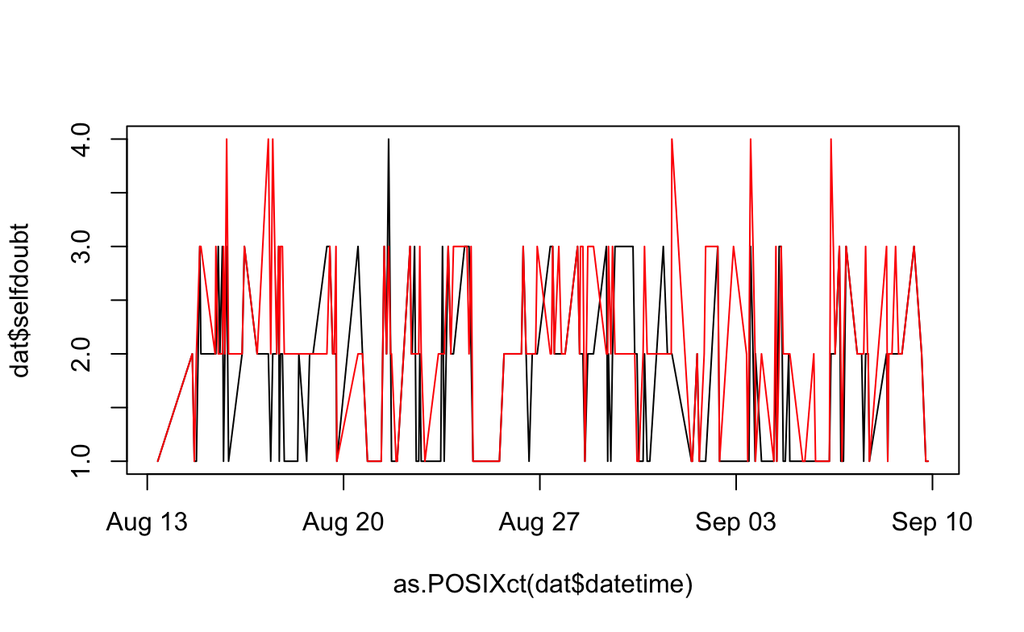

```r
plot(as.POSIXct(dat$datetime), dat$selfdoubt, type = "l")
lines(as.POSIXct(dat$datetime), dat$tired, col = "red")
```

Similar to an autocorrelation scatter plot, you can plot the cross-lagged relations; one with $y_t$ versus $x_{t-1}$ and one with $x_t$ versus $y_{t-1}$.

Make cross-lagged relation scatter plots for `self-doubt` versus `tired`, and vice versa.

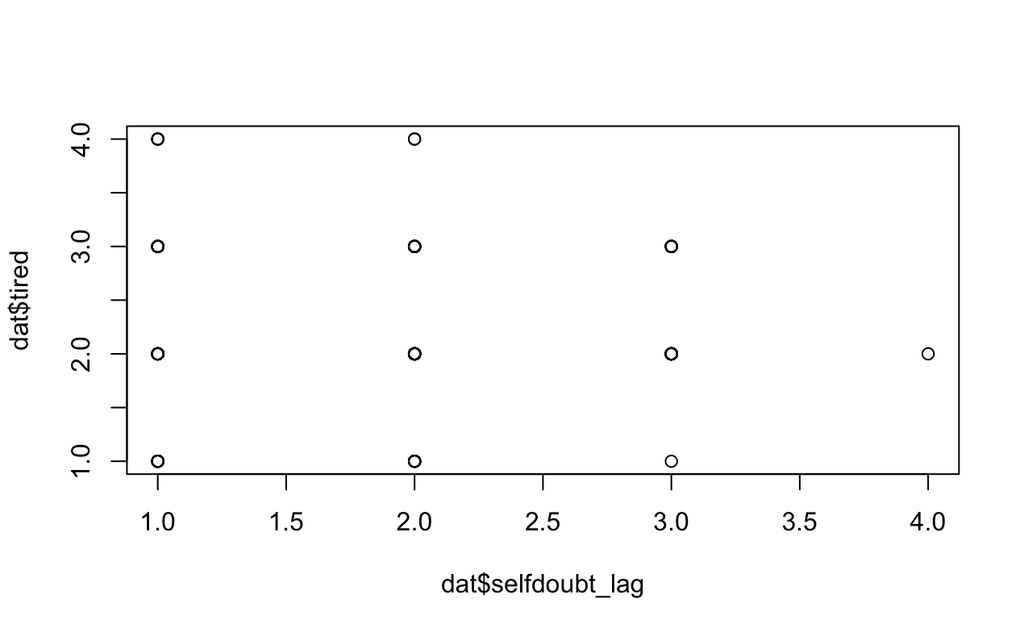

```r
plot(dat$selfdoubt_lag, dat$tired)
```

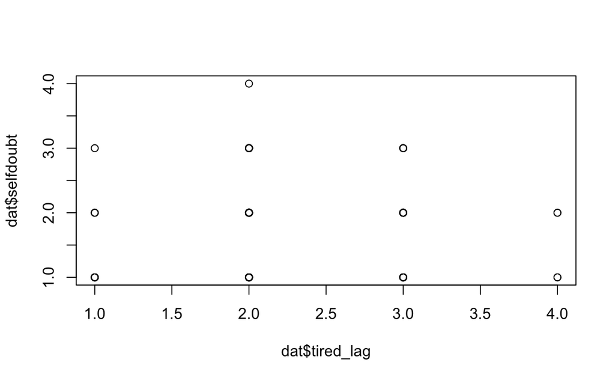

```r
plot(dat$tired_lag, dat$selfdoubt)
```

### Fit the VAR(1) model

First, estimate two univariate models, one with `selfdoubt` as outcome and one with `tired` as outcome, and the lagged versions of both variables as predictors. Center the predictors if you want the intercept to represent the mean of the process.

```r
# univariate model outcome selfdoubt
var_selfdoubt <- lm(selfdoubt ~ selfdoubt_lag + tired_lag, data = dat)
# univariate model outcome tired
var_tired <- lm(tired ~ tired_lag + selfdoubt_lag, data = dat)
```

Answer the following questions:

- Are the autoregressive effects similar as the AR(1) model?

In this case, the autoregressive effects are similar to the univariate AR(1) model.

- Is there a cross-lagged effect from `selfdoubt` to `tired`?

No, the cross-lagged regression estimate from `selfdoubt` to `tired` is estimated to be $-0.0003$.

- Is there a cross-lagged effect from `tired` to `selfdoubt`? The cross-lagged regression estimate from `tired` to `selfdoubt` is estimated to be $-0.1075$. However, it is not significant (see `coef(var_selfdoubt)`)
- How would you interpret the cross-lagged effects? The cross-lagged regression estimate from `tired` to `selfdoubt` you could interpret as people who were more tired at one accoasion had less selfdoubt at the next occasion.

Unfortunately, with univariate estimation we cannot always estimate the covariance between the residuals. As is the case here: because of different missing value patterns, the residuals of the two models do not match. A solution would be to remove all incomplete cases in the full data set (e.g., using `na.omit`). You can then extract the residuals, for example using the `residuals()` function from the `stats` package, and compute the covariance/correlation between them.

Remove all missing cases from the data and fit the two univariate AR(1) models again. Compute the covariance between the residuals of the two models.

```r
# univariate model outcome selfdoubt
var_selfdoubt2 <- lm(selfdoubt ~ selfdoubt_lag + tired_lag, data = na.omit(dat))
# univariate model outcome tired
var_tired2 <- lm(tired ~ tired_lag + selfdoubt_lag, data = na.omit(dat))

cov(residuals(var_selfdoubt2), residuals(var_tired2))
```

```
[1] 0.3102336
```

A more elegant approach would be to estimate the VAR(1) model multivariately. The `vars` package is unfortunately not an option here, as it cannot handle missing data. We can, however, use the `var1()` function from the `psychonetrics` package for this. Conveniently, it has build-in functionality to handle lags and separate days and beeps in ESM data, through the arguments `dayvar` and `beepvar`, for which you have to provide to column names that indicate the days and the beep numbers, respectively. After you specified the model with the `var1()` function, you can fit the model with the `runmodel()` function. Finally, you can extract the parameter estimates with the `parameters()` function.

The package has very extensive documentation, see e.g., https://psychonetrics.org/var1.html.

Fit a multivariate VAR(1) model.

```r
parameters(mod_var)
```

```
 Parameters for group fullsample
    -  mu
           var1 op var2  est    se        p row col par
 selfdoubt_lag1 ~1      1.93 0.072 < 0.0001   1   1   1
     tired_lag1 ~1      2.23 0.065 < 0.0001   2   1   2
      selfdoubt ~1      1.84 0.057 < 0.0001   3   1   3
          tired ~1      2.14 0.056 < 0.0001   4   1   4

    -  exo_cholesky
           var1     op           var2  est    se        p row col par
 selfdoubt_lag1 ~chol~ selfdoubt_lag1 0.76 0.051 < 0.0001   1   1   5
     tired_lag1 ~chol~ selfdoubt_lag1 0.36 0.061 < 0.0001   2   1   6
     tired_lag1 ~chol~     tired_lag1 0.58 0.039 < 0.0001   2   2   7

    -  beta
      var1 op      var2    est   se    p row col par
 selfdoubt <- selfdoubt   0.16 0.12 0.16   1   1   8
     tired <- selfdoubt 0.0094 0.11 0.93   2   1   9
 selfdoubt <-     tired  -0.11 0.11 0.33   1   2  10
     tired <-     tired 0.0038 0.11 0.97   2   2  11

    -  sigma_zeta (symmetric)
      var1 op      var2  est    se        p row col par
 selfdoubt ~~ selfdoubt 0.56 0.061 < 0.0001   1   1  12
     tired ~~ selfdoubt 0.31 0.048 < 0.0001   2   1  13
     tired ~~     tired 0.55 0.059 < 0.0001   2   2  14
```

When looking at the output of the `parameters()` function, you will see the estimated means (`mu`), the regression coefficients (`beta`), and the covariance matrix of the residuals (`sigma_zeta`).

Answer the following questions:

- Are the means and regression coefficients similar to the univariate estimates?

They are similar.

- Is the estimated residual covariance similar to the one you computed from the univariate residuals?

The covariance from the univariate residuals was $0.310$ and the estimated covariance here (at sigma_zeta, tired selfdoubt) is $0.31$, so similar.